# Practical Machine Learning - Prediction Assignment

TermiJAG

Sunday, July 24, 2016

## Background

Using devices such as Jawbone Up, Nike FuelBand, and Fitbit it is now possible to collect a large amount of data about personal activity relatively inexpensively. These type of devices are part of the quantified self movement - a group of enthusiasts who take measurements about themselves regularly to improve their health, to find patterns in their behavior, or because they are tech geeks. One thing that people regularly do is quantify how much of a particular activity they do, but they rarely quantify how well they do it. In this project, your goal will be to use data from accelerometers on the belt, forearm, arm, and dumbell of 6 participants. They were asked to perform barbell lifts correctly and incorrectly in 5 different ways. More information is available from the website here: http://groupware.les.inf.puc-rio.br/har (see the section on the Weight Lifting Exercise Dataset).

## Data

The training data for this project are available here:

https://d396qusza40orc.cloudfront.net/predmachlearn/pml-training.csv

The test data are available here:

https://d396qusza40orc.cloudfront.net/predmachlearn/pml-testing.csv

### Data Processing

Loading datasets from local folder

```r
set.seed(12345)
setwd("C://Users//Jascha//Desktop")
trainData = read.csv("pml-training.csv", na.strings=c("", "NA", "NULL"))
testData = read.csv("pml-testing.csv", na.strings=c("", "NA", "NULL"))
```

Removing variables with too many NAs

```r
trainingSet <- trainData[ , colSums(is.na(trainData)) == 0]
```

There are some irrelevant variables that can be removed

```r
removeVars = c('X', 'user_name', 'raw_timestamp_part_1', 'raw_timestamp_part_2', 'cvtd_timestamp', 'new_window', 'num_window')
trainingSet<- trainingSet[, -which(names(trainingSet) %in% removeVars)]
```

Check for numeric variables with low variance

```r
zeroVar= nearZeroVar(trainingSet[sapply(trainingSet, is.numeric)], saveMetrics = TRUE)
trainingSet= trainingSet[,zeroVar[, 'nzv']==0]
```

Remove highly correlated variables

```r
corrMatrix <- cor(na.omit(trainingSet[sapply(trainingSet, is.numeric)]))
removecorrelated = findCorrelation(corrMatrix, cutoff = .90, verbose = TRUE)
```

```
## Compare row 10  and column  1 with corr  0.992
##   Means:  0.27 vs 0.168 so flagging column 10
## Compare row 1  and column  9 with corr  0.925
##   Means:  0.25 vs 0.164 so flagging column 1
## Compare row 9  and column  4 with corr  0.928
##   Means:  0.233 vs 0.161 so flagging column 9
## Compare row 8  and column  2 with corr  0.966
##   Means:  0.245 vs 0.157 so flagging column 8
## Compare row 19  and column  18 with corr  0.918
##   Means:  0.091 vs 0.158 so flagging column 18
## Compare row 46  and column  31 with corr  0.914
##   Means:  0.101 vs 0.161 so flagging column 31
## Compare row 46  and column  33 with corr  0.933
##   Means:  0.083 vs 0.164 so flagging column 33
## All correlations <= 0.9
```

```r
trainingSet= trainingSet[,-removecorrelated]
dim(trainingSet)
```

```
## [1] 19622    46
```

```r
inTrain <- createDataPartition(y=trainingSet$classe, p=0.7, list=FALSE)
training <- trainingSet[inTrain,];
testing <- trainingSet[-inTrain,]
dim(training)
```

```
## [1] 13737    46
```

```r
dim(testing)
```

```
## [1] 5885   46
```

## Analysis

We analyse the data with the tree package and plot it

```r
library(tree)
set.seed(12345)
tree.training=tree(classe~.,data=training)
summary(tree.training)
```

```
##
## Classification tree:
## tree(formula = classe ~ ., data = training)
## Variables actually used in tree construction:
##  [1] "pitch_forearm"     "magnet_belt_y"     "accel_forearm_z"
##  [4] "magnet_dumbbell_y" "roll_forearm"      "magnet_dumbbell_z"
##  [7] "accel_dumbbell_y"  "pitch_belt"        "yaw_belt"
## [10] "yaw_dumbbell"      "accel_forearm_x"   "magnet_forearm_y"
## [13] "accel_dumbbell_z"  "gyros_belt_z"
## Number of terminal nodes:  20
## Residual mean deviance:  1.676 = 22990 / 13720
## Misclassification error rate: 0.3245 = 4457 / 13737
```

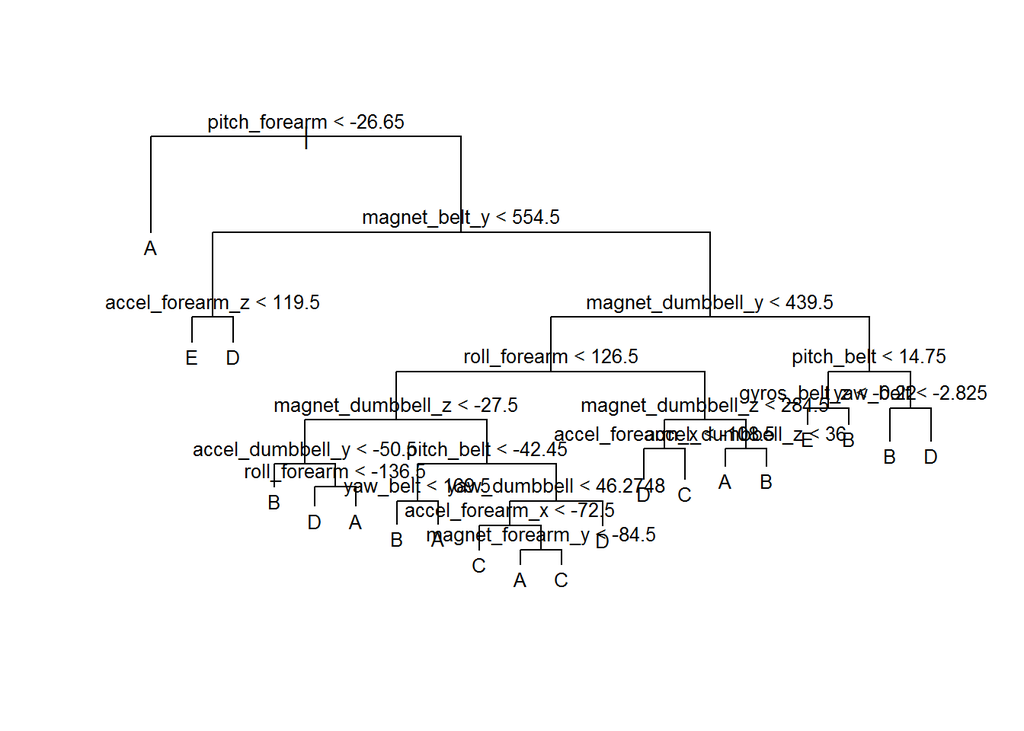

```r
plot(tree.training)
text(tree.training,pretty=0, cex =.8)
```

```r
rpartFit <- train(classe ~ .,method="rpart",data=training)
print(rpartFit$finalModel)
```

```
## n= 13737
##
## node), split, n, loss, yval, (yprob)
##       * denotes terminal node
##
##   1) root 13737 9831 A (0.28 0.19 0.17 0.16 0.18)
##     2) pitch_forearm< -26.65 1223   63 A (0.95 0.052 0 0 0) *
##     3) pitch_forearm>=-26.65 12514 9768 A (0.22 0.21 0.19 0.18 0.2)
##       6) magnet_belt_y>=555.5 11479 8736 A (0.24 0.23 0.21 0.18 0.15)
##        12) yaw_belt>=169.5 570   56 A (0.9 0.047 0 0.051 0) *
##        13) yaw_belt< 169.5 10909 8342 B (0.2 0.24 0.22 0.19 0.15)
##          26) magnet_dumbbell_z< -87.5 1427  629 A (0.56 0.28 0.045 0.081 0.034) *
##          27) magnet_dumbbell_z>=-87.5 9482 7152 C (0.15 0.23 0.25 0.2 0.17)
##            54) pitch_belt< -42.95 589   93 B (0.022 0.84 0.088 0.029 0.019) *
##            55) pitch_belt>=-42.95 8893 6615 C (0.16 0.19 0.26 0.21 0.18)
##             110) magnet_dumbbell_x< -446.5 4974 3074 C (0.16 0.11 0.38 0.21 0.14) *
##             111) magnet_dumbbell_x>=-446.5 3919 2788 B (0.16 0.29 0.096 0.21 0.24)
##               222) yaw_belt< 4.41 3519 2389 B (0.18 0.32 0.1 0.24 0.16) *
##               223) yaw_belt>=4.41 400   20 E (0 0.0025 0.048 0 0.95) *
##       7) magnet_belt_y< 555.5 1035  187 E (0.0029 0.00097 0.0019 0.17 0.82) *
```

```r
library(rattle)
```

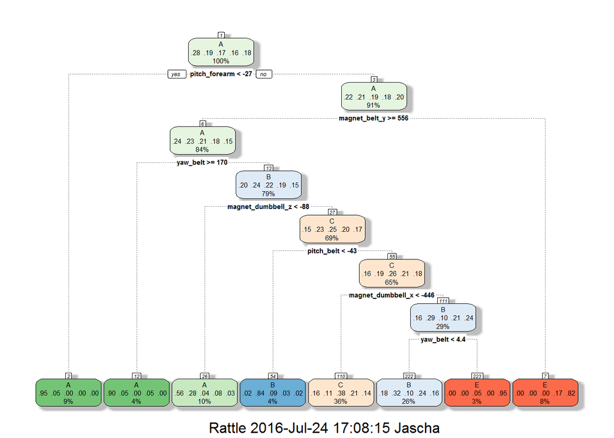

```r
fancyRpartPlot(rpartFit$finalModel)
```

### Random Forests

The third method is Random Forests

```r
require(randomForest)
set.seed(12345)
rf.training=randomForest(classe~.,data=training,ntree=100, importance=TRUE)
rf.training
```

```
##
## Call:
##  randomForest(formula = classe ~ ., data = training, ntree = 100,      importance = TRUE)
##                Type of random forest: classification
##                      Number of trees: 100
## No. of variables tried at each split: 6
##
##         OOB estimate of  error rate: 0.73%
## Confusion matrix:
##      A    B    C    D    E  class.error
## A 3903    2    0    0    1 0.0007680492
## B   25 2622    9    2    0 0.0135440181
## C    1   19 2372    4    0 0.0100166945
## D    0    0   25 2222    5 0.0133214920
## E    1    0    2    4 2518 0.0027722772
```

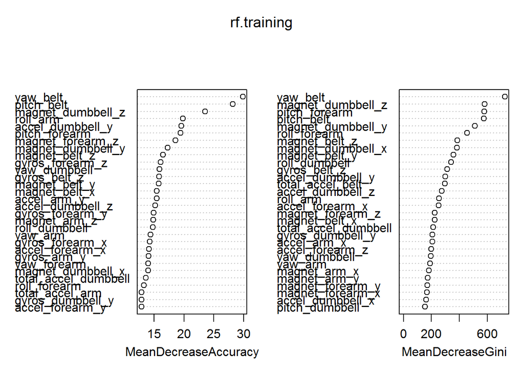

```r
varImpPlot(rf.training,)
```

We can see the impact the variables have on the prediction.

### Cross Validation

We are checking the performance by cross validation using the test set of the original training set.

```r
#Tree
tree.pred=predict(tree.training,testing,type="class")
predMatrix = with(testing,table(tree.pred,classe))
sum(diag(predMatrix))/sum(as.vector(predMatrix))
```

```
## [1] 0.6669499
```

```r
#RPart
tree.pred=predict(rpartFit,testing)
predMatrix = with(testing,table(tree.pred,classe))
sum(diag(predMatrix))/sum(as.vector(predMatrix))
```

```
## [1] 0.5233645
```

```r
#Random Forest
tree.pred=predict(rf.training,testing,type="class")
predMatrix = with(testing,table(tree.pred,classe))
sum(diag(predMatrix))/sum(as.vector(predMatrix))
```

```
## [1] 0.9909941
```

## Conclusion

We can predict the testing data using the random forest method.

```r
answers <- predict(rf.training, testData)
answers
```

```
##  1  2  3  4  5  6  7  8  9 10 11 12 13 14 15 16 17 18 19 20
##  B  A  B  A  A  E  D  B  A  A  B  C  B  A  E  E  A  B  B  B
## Levels: A B C D E
```

Submitting the results to the website in the quiz gives us 20/20 points. Good Model.